# RStudio Workshop for S&C Coaches

Beginners level. No familiarity with R.

Jose Fernandez

19 August, 2020

# What we will learn

- Basic intro to R and Rstudio
- The difference between packages and functions
- Loading packages
- Importing data
- Familiarising yourself with the data
- Basic statistical operations we can perform on our data
- Creating and improving graphics
- Joining different datasets
- Basic data modeling

# Programming in R

It is important to differenciate between `R` and `RStudio`.

- R is a **programming language** use (amongst other things) for statistical analysis. It is commonly used by analysts and data scientists in different fields, including sports.

To download R, please follow this [link.](https://cran.r-project.org/bin/windows/base/)

- RStudio is the **interface** that enables users to write R scripts in a variety of formats, often more user friendly that using R alone. It is a powerful development environment where users can organise their scripts, see outputs alongside code or even write interactive web applications.

To download the R Studio software follow this [link.](https://rstudio.com/products/rstudio/download/%5D)

R Programming language is ~20 years old and the most recent version of the language *(Version 4.00)* was released in February 2020. On the other side Rstudio is just a few years old, but it has evolved a lot in just a few years. There are other platforms besides RStudio that can be used to write R, but Rstudio is a very common one.

To summarise the relationship between these two elements, try to think of R like the engine of the car and Rstudio like the driving wheel and dashboard from where you can control the engine.

#### The image below is a summary of what the Rstudio interface looks like after you install it and some of the background behind the different parts of the software.

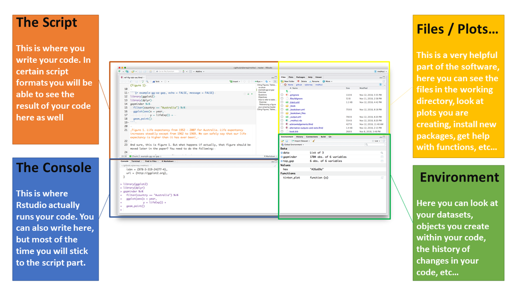

#### Furthermore, the header Menu provides a variety of functionalities that you should try to get familiar with when you start using RStudio as it will help you save time.

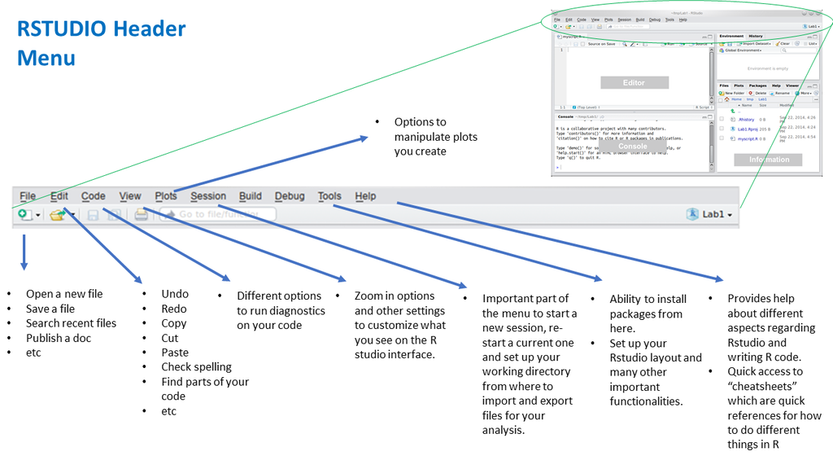

# Why R?

There are a few reasons why R is a good option for statistical analysis. Some of those are:

- It is a powerful programming, statistical and graphical language that will cover most of your analytical needs.
- It is free and open source. It is constantly evolving and getting better.
- There are packages (thousands of them) that provide functions for users to perform different tasks.
- You can write your own functions (and packages) if you want to, to suit your needs. This will simplify your code if you have to repeat certain steps a few times in your script.
- Automate your script. Unlike excel, you can fully automate your script without the need to repeat it every time you need something.
- It handles big volumes of data really well.
- You can design powerful graphics. There are some packages that can help you achieve almost anything you want.
- You can use it to create reports (like this document) or even full apps like our AMS.

Most of the above bullet points also apply to other programming languages (Python for example). But for now, we are going to focus on R and some of it possibilities.

# Packages / Functions

Packages are `group of functions` packaged together. They are also called *libraries*. There are thousands of packages in R. Some for data manipulation, some for statistical analysis, some for data visualization and even specific packages to create reports and full applications.

`Functions perform specific taks` (*i.e: calculate the mean of a list of numbers*). They are similar to the functions you use in Excel for example. In R, functions follow the following pattern **function_name(something)**.

One advantage of R is that users can create their own functions and packages for many different needs.

Think of a function as a wrapper for steps you want to perform within your analysis. If you write the steps once, and wrap then within a function, then instead of repeating those steps you can just call your functions. Your call will be more organised this way.

In the near future we will learn how to write our own functions.

Let's load the packages we are going to use in this session

```r
library(tidyverse) #loads all the packgages in the tidyverse ecosystem
library(readxl) #loads the readxl package, which makes it easy to import xlsx files.
```

The **Tidyverse** is a very important package in R. In fact, it is more than just a package. `It is universe of packages`, meaning it loads a few packages that provide a wide array of useful functions for data analysis. It provides functions to import data, to clean, manipulate and tidy your data prior to analysis as well as for data modeling and visualization. It integrates the *ggplot2* package, which is probably one of the most important data visualization packages out there. To learn more about the Tidyverse package visit this [link.](https://www.tidyverse.org/)

# Importing your data

We are going to load a few datasets and give them names, so that we can call them later in the analysis process if we need to. To name something in R just follow this pattern: **name** `<-` **something**

```r
strength <- read.csv("strength.csv") #loading max strength data and calling it "strength"
power <- read.csv("power.csv") #loading power data and calling it "power"
speed <- read_excel("speed.xlsx") #loading running speed data and call it "speed"
```

Notice the different functions we used to import data. **"read.csv()"** is a native R function. We don't need any packages to run it.

However, `speed is not a .csv document but a .xlsx file`, therefore we need another funtion to import this document. We use **"read_excel()"** from the `"readxl"` package, which we loaded at the beginning.

R allows to import many different types of files, like .pdf, .txt, .csv, .tsv, .xls, etc... and it also allows to connect directly to a database. For example, we can connect directly to our team's database using specific packages for this. This way, every time we run our code we are always pulling the most updated data.

# Data Transformation

Now that our the data is loaded we are ready to start working with it. Real data is always messy and you will have to do some sort of cleaning and tyding all the time. We are going to clean each of those datasets to facilitate our analysis later.

```r
#Prepare the strength dataset
strength.C <- strength %>%
  select(Date, Player, maxStrength = Estimated.1RM) %>%
  mutate(Date = as.Date(Date, origin = "1970-01-01", format = "%m/%d/%Y"))

#prepare the power dataset
power.c <- power %>%
  select(Date, Player, relPower = Value) %>%
  mutate(Date = as.Date(Date, origin = "1970-01-01", format = "%m/%d/%Y"))

#prepare the speed dataset
speed.c <- speed %>%
  select(Date, Player = player, maxSpeed = Total) %>%
  mutate(Date = as.Date(Date, origin = "1970-01-01", format = "%m/%d/%Y"))
```

We have done some data cleaning, for example we selected especific columns for each dataset using `select()`, and we also changed the name of a few columns to make them more meaningful within the *select()* function.

Notice the *pipe* operator (**%>%**). This symbol is called `pipe`. It helps join statements in your code, in English it could be translated as **"then"**.

On the example above you are basically saying use the dataset "speed" **and then** select the following 3 columns **and then** change the date format from text to date.

You can *pipe* your code when the Tidyverse package is loaded.